## Machine Learning Course Project: Human Activity Recognition

S. Massie  
Coursera / Johns Hopkins University: Practical Machine Learning  
October 25, 2015

## 1. Overview

The dataset http://groupware.les.inf.puc-rio.br/har includes electronic sensor data from six test subjects who performed a barbell exercise. Each record was then assigned a Class from “A” to “E” based on whether the exercise was performed correctly.

In this project, I build a model to predict the Class from the exercise data. Data was split into “training” (80%) and “probe” (20%) datasets. 100 variables of primarily blank or NA variables were removed, and some observations which appeared to be from a different dataset were filtered out. Additionally, quantative (non-factor) variables were combined using Principal Components Analysis (PCA), and outliers representing 0.67% of the dataset were removed.

## Getting and cleaning data

Data was downloaded from the Coursera website and extracted to the “exTrain” data frame.

Notice that a large number of variables (100) are mostly NA or blank values, while the rest (60) have none. Remove these variables.

```r
# Replace blank values with NAs
exTrain <- replace(exTrain, exTrain=="", NA)

# Create list of columns which contain NAs:
NAcols <- logical(length = 160)
for(i in 1:160) NAcols[i] <- any(is.na(exTrain[,i]))

# Select only columns which do not contain NAs
library(dplyr)
exTrain <- select(exTrain, which(!NAcols))
```

## Data slicing

Subdivide the original training set into “training” (80%) and “probe” (20%) sets so that we can perform cross validation.

## Feature selection

Also remove timestamp variables for simplicity. I assume that the timestamp variable by itself, would not very useful as a predictor of *future* lifting, even if it proves useful in cross validation.

```r
training <- filter(training, new_window == "no")
training <- select(training, -new_window, -raw_timestamp_part_1,
                   -raw_timestamp_part_2, -cvtd_timestamp)
```

## Pre-processing

Note that many variables in this dataset appear to be the same measurements of x, y, and z axis. For instance, “accel_arm_x”, “accel_arm_y”, and “accel_arm_z” are three variables.

Use PCA to create combinations of quantitative motion variables, and recombine the PCA variables with factor variables:

```r
# Select only quantiative variables
training_quant <- select(training, -X, -user_name, -num_window, -classe)

# Perform PCA on these variables to capture 95% of variance.  (Can try other tresholds later)
PCAvars <- preProcess(training_quant, method = "pca", thresh = 0.95)

# Predict PCA values for training dataset, and recombine with factor variables
training_PCA <- predict(PCAvars, training_quant)

training_PCA <- mutate(training_PCA, user_name=training$user_name,
                num_window = training$num_window, classe = training$classe)
```

## Checking for outliers

After creating exploratory plots of “classe” aginst factor variables, “X”, “user_name”, and “num_window”, notice there is exact correlation between “classe” and “X”, so we also remove X from the dataset.

Create an exploratory plot showing histograms of PCA variables:

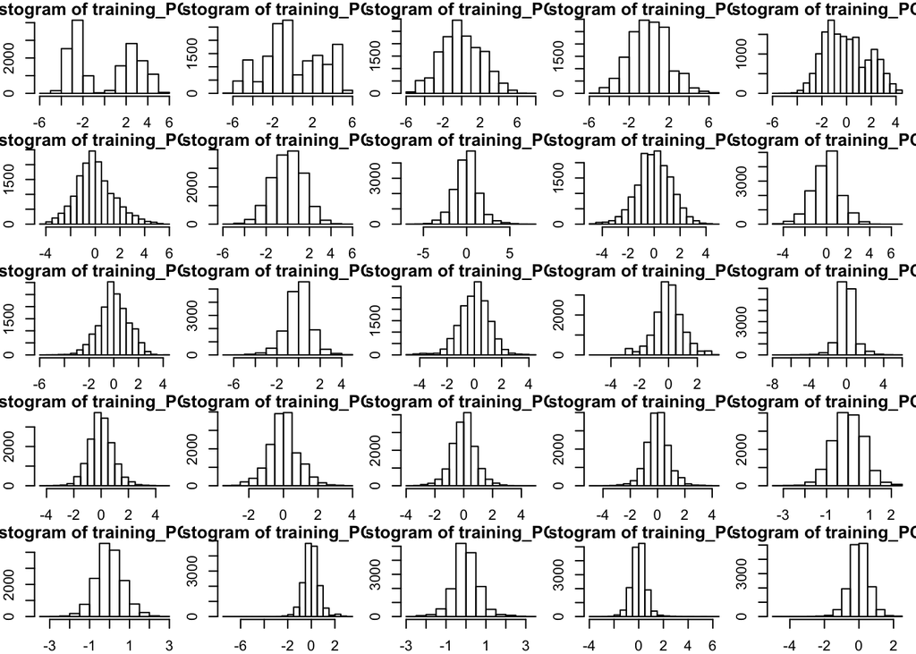

```r
par(mfrow = c(5,5), mar = c(2,2,1,0.5))
for(i in 1:25){
    hist(training_PCA[,i])
}
```

Flag rows with outliers:

```r
# Remove PCA variables which are more than 6 units (standard deviations) from mean
outly <- function(x, range) which(abs(x) >= range)

outliers <- numeric()
for(i in 1:25){
    outliers <- unique(c(outliers,outly(training_PCA[,i], 6)))
}
```

These values represent only 0.67% of the dataset. Since we are interested predicting in “correct” behaviors, as opposed to rare events, we will remove these outliers to improve model accuracy while training the model.

## Model training

I choose a classification tree-based model over a GLM-based model because we are trying to model a categorial variable. Here, random forest is used.

```r
# Training: caret package version
if(!exists("model2")){
    model2 <- train(classe ~., data=training_PCA[-outliers,], method = "rf")
}
```

## Error rates and Cross validation

Preprocess “probe” dataset according to same steps as “training” dataset:

Next, predict values in probe dataset using model.

```r
probe_y <- predict(model2, newdata = select(probe_PCA, -classe))
```

Compare predicted to actual values and show confusion matrix:

```r
confM <- confusionMatrix(probe_y, probe_PCA$classe)
confM
```

```
## Confusion Matrix and Statistics
##
##           Reference
## Prediction    A    B    C    D    E
##          A 1093    0    0    0    0
##          B    0  746    1    0    0
##          C    0    1  666    1    0
##          D    1    0    0  628    0
##          E    0    0    0    1  710
##
## Overall Statistics
##
##                Accuracy : 0.9987
##                  95% CI : (0.997, 0.9996)
##     No Information Rate : 0.2843
##     P-Value [Acc > NIR] : < 2.2e-16
##
##                   Kappa : 0.9984
##  Mcnemar's Test P-Value : NA
##
## Statistics by Class:
##
##                      Class: A Class: B Class: C Class: D Class: E
## Sensitivity            0.9991   0.9987   0.9985   0.9968   1.0000
## Specificity            1.0000   0.9997   0.9994   0.9997   0.9997
## Pos Pred Value         1.0000   0.9987   0.9970   0.9984   0.9986
## Neg Pred Value         0.9996   0.9997   0.9997   0.9994   1.0000
## Prevalence             0.2843   0.1941   0.1733   0.1637   0.1845
## Detection Rate         0.2840   0.1939   0.1731   0.1632   0.1845
## Detection Prevalence   0.2840   0.1941   0.1736   0.1635   0.1848
## Balanced Accuracy      0.9995   0.9992   0.9989   0.9983   0.9998
```

## Predicting test values

As a final step, the model is used to predict values for the “test” dataset of 20 records provided by coursera.

Predict new values.

```r
test_y <- predict(model2, newdata = test_PCA)
test_y
```

```
##  [1] B A B A A E D B A A B C B A E E A B B B
## Levels: A B C D E
```

The model generates a set of predictions for the test variable.

## Old code / appendix

Counting NA values:

Plotting Y aginst factor Xs.

Checking ranges.

Creating model with RandomForest package: